# August Employee and Client Analysis Report

```python
import pandas as pd
import numpy as np
import matplotlib.pyplot as plt
```

Importing the Necessary Python libraries for our Project Analysis

## Reading the August Data Dump Dataset.

We read the data set and specify the excel sheet were working on before we start our analysis. we will also specify the date `August 17th 2023`

```python
# Loading the "August Data Dump" sheet from the provided Excel file using the user's code snippet
august_data_dump_path = r'C:\Users\moses_y\OneDrive\Desktop\ML Projects\maggyspr\Data\Daily Production Tracker 080123 (1).xlsx'
august_data_dump = pd.read_excel(august_data_dump_path, sheet_name='August Data Dump', skiprows=3)

# Filtering the data to include only the records from the date 2023-08-17
date_filtered_data = august_data_dump[august_data_dump['Date'] == '2023-08-17']
date_filtered_data.head()

# Load the dataset (Replace with actual code to load your data)
#data = pd.read_csv(r"C:\Users\moses_y\OneDrive\Desktop\ML Projects\maggyspr\Data\Daily Production Tracker 080123 (1).xlsx")

# Show the first few rows
#data.head()
```

|  | Date | Client | Project | Staff | Box | Function | Image Count | Time (minutes) | Standard | Unnamed: 9 | Status | Unnamed: 11 | Unnamed: 12 | Unnamed: 13 | Preparation | 3 | 180 |
| --- | --- | --- | --- | --- | --- | --- | --- | --- | --- | --- | --- | --- | --- | --- | --- | --- | --- |
| 218 | 2023-08-17 | LION PROTECT | MAUDLIN | Barber | 36 | PREP | NaN | 150 | 180.0 | NaN | NaN | NaN | NaN | NaN | NaN | NaN | NaN |
| 219 | 2023-08-17 | LION PROTECT | MAUDLIN | Hankerson | 22 | QC/REASSEMBLE | NaN | 150 | 180.0 | NaN | NaN | NaN | NaN | NaN | NaN | NaN | NaN |
| 220 | 2023-08-17 | LION PROTECT | MAUDLIN | Hankerson | 22 | QC/REASSEMBLE | NaN | 45 | 180.0 | NaN | NaN | NaN | NaN | NaN | NaN | NaN | NaN |
| 221 | 2023-08-17 | LION PROTECT | MAUDLIN | Hankerson | 22 | QC/REASSEMBLE | NaN | 30 | 180.0 | NaN | NaN | NaN | NaN | NaN | NaN | NaN | NaN |
| 222 | 2023-08-17 | CCHMC | MAILROOM | Hankerson | NaN | PREP | NaN | 135 | 180.0 | NaN | NaN | NaN | NaN | NaN | NaN | NaN | NaN |

```python
# Filtering the data to include only the records from the date 2023-08-17
date_filtered_data = august_data_dump[august_data_dump['Date'] == '2023-08-17']
date_filtered_data.head()
```

|  | Date | Client | Project | Staff | Box | Function | Image Count | Time (minutes) | Standard | Unnamed: 9 | Status | Unnamed: 11 | Unnamed: 12 | Unnamed: 13 | Preparation | 3 | 180 |
| --- | --- | --- | --- | --- | --- | --- | --- | --- | --- | --- | --- | --- | --- | --- | --- | --- | --- |
| 218 | 2023-08-17 | LION PROTECT | MAUDLIN | Barber | 36 | PREP | NaN | 150 | 180.0 | NaN | NaN | NaN | NaN | NaN | NaN | NaN | NaN |
| 219 | 2023-08-17 | LION PROTECT | MAUDLIN | Hankerson | 22 | QC/REASSEMBLE | NaN | 150 | 180.0 | NaN | NaN | NaN | NaN | NaN | NaN | NaN | NaN |
| 220 | 2023-08-17 | LION PROTECT | MAUDLIN | Hankerson | 22 | QC/REASSEMBLE | NaN | 45 | 180.0 | NaN | NaN | NaN | NaN | NaN | NaN | NaN | NaN |
| 221 | 2023-08-17 | LION PROTECT | MAUDLIN | Hankerson | 22 | QC/REASSEMBLE | NaN | 30 | 180.0 | NaN | NaN | NaN | NaN | NaN | NaN | NaN | NaN |
| 222 | 2023-08-17 | CCHMC | MAILROOM | Hankerson | NaN | PREP | NaN | 135 | 180.0 | NaN | NaN | NaN | NaN | NaN | NaN | NaN | NaN |

```python
date_filtered_data.describe()
```

|  | Date | Image Count | Standard | Unnamed: 9 | Status | Unnamed: 13 | 3 | 180 |
| --- | --- | --- | --- | --- | --- | --- | --- | --- |
| count | 21 | 4.000000 | 21.000000 | 0.0 | 0.0 | 0.0 | 0.0 | 0.0 |
| mean | 2023-08-17 00:00:00 | 1613.250000 | 140.714286 | NaN | NaN | NaN | NaN | NaN |
| min | 2023-08-17 00:00:00 | 220.000000 | 15.000000 | NaN | NaN | NaN | NaN | NaN |
| 25% | 2023-08-17 00:00:00 | 457.750000 | 120.000000 | NaN | NaN | NaN | NaN | NaN |
| 50% | 2023-08-17 00:00:00 | 1672.000000 | 180.000000 | NaN | NaN | NaN | NaN | NaN |
| 75% | 2023-08-17 00:00:00 | 2827.500000 | 180.000000 | NaN | NaN | NaN | NaN | NaN |
| max | 2023-08-17 00:00:00 | 2889.000000 | 180.000000 | NaN | NaN | NaN | NaN | NaN |
| std | NaN | 1432.019175 | 56.220230 | NaN | NaN | NaN | NaN | NaN |

```python
# Checking the unique values in the "Function" column
unique_functions = date_filtered_data['Function'].unique()
unique_functions
```

```
array(['PREP', 'QC/REASSEMBLE', 'SCAN/QC', 'DATA MGT', 'SCAN', 'COURIER'],
      dtype=object)
```

The "Function" column contains six unique activity codes: 'PREP', 'QC/REASSEMBLE', 'SCAN/QC', 'DATA MGT', 'SCAN', and 'COURIER'.

```python
# Checking the unique values in the "Staff" column
unique_staff = date_filtered_data['Staff'].unique()
unique_staff
```

```
array(['Barber', 'Hankerson', 'Tinsley', 'Watkins', 'Renneker', 'Walker'],
      dtype=object)
```

The "Staff" column contains six unique staff names: 'Barber', 'Hankerson', 'Tinsley', 'Watkins', 'Renneker', 'Walker'.

```python
# Checking the unique values in the "Client" column
unique_clients = date_filtered_data['Client'].unique()
unique_clients
```

```
array(['LION PROTECT', 'CCHMC', 'AK STEEL ', 'INTERNAL', 'COURIER'],
      dtype=object)
```

The "Client" column contains 5 unique client names: 'LION PROTECT', 'CCHMC', 'AK STEEL ', 'INTERNAL', 'COURIER'.

```python
# Checking the data types of the "Time (minutes)" column for each unique function
time_data_types_per_function = {function: date_filtered_data[date_filtered_data['Function'] == function]['Time (minutes)'].dtype for function in unique_functions}
time_data_types_per_function
```

```
{'PREP': dtype('O'),
 'QC/REASSEMBLE': dtype('O'),
 'SCAN/QC': dtype('O'),
 'DATA MGT': dtype('O'),
 'SCAN': dtype('O'),
 'COURIER': dtype('O')}
```

The "Time (minutes)" column has an object data type for all functions, which indicates that there might be non-numeric values present in this column.

```python
# Checking a sample of the "Time (minutes)" column to inspect the values
time_minutes_sample = date_filtered_data['Time (minutes)'].sample(10)
time_minutes_sample
```

```
218    150
235     60
234     75
228    135
221     30
233     30
220     45
223     75
226    216
230     30
Name: Time (minutes), dtype: object
```

The values in the "Time (minutes)" column appear to be numerical, but the data type is still an object. This discrepancy might be caused by some hidden characters or other non-numeric values in the column.

To resolve this issue, we'll convert the "Time (minutes)" column to a numerical data type, handling any non-convertible values appropriately by using `errors=coerce`, and then proceed with our analysis.

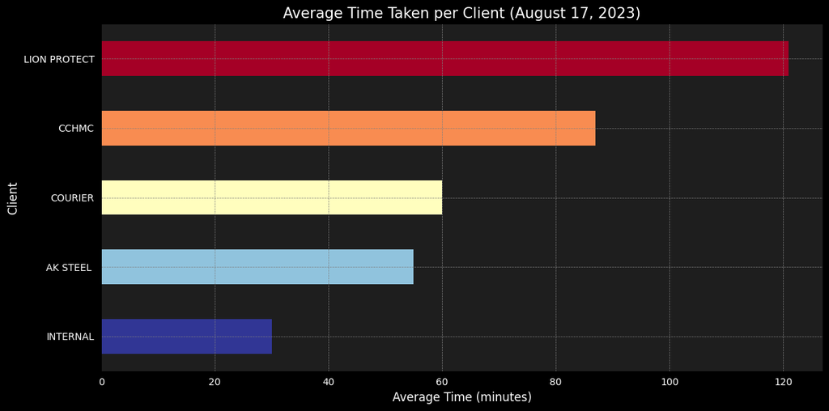

```python
# Converting the "Time (minutes)" column to a numerical data type
date_filtered_data['Time (minutes)'] = pd.to_numeric(date_filtered_data['Time (minutes)'], errors='coerce')


# High-level data science plot for average time taken per client
plt.figure(figsize=(12, 6), facecolor='black')
avg_time_per_client = date_filtered_data.groupby('Client')['Time (minutes)'].mean().sort_values()

# Creating a color map to represent the time taken
colors = plt.cm.RdYlBu_r(np.linspace(0, 1, len(avg_time_per_client)))

avg_time_per_client.plot(kind='barh', color=colors)
plt.title('Average Time Taken per Client (August 17, 2023)', fontsize=15, color='white')
plt.xlabel('Average Time (minutes)', fontsize=12, color='white')
plt.ylabel('Client', fontsize=12, color='white')
plt.xticks(color='white')
plt.yticks(color='white')
plt.gca().set_facecolor('#1e1e1e')
plt.grid(color='gray', linestyle='--', linewidth=0.5)
plt.tight_layout()
plt.show()
```

LION PROTECT:lion protect tasks take the most time on average, with about 120 minutes on this client.

CHILD SERVICES: tasks for this client takes around 85 minutes on average.

COURIER: tasks takes around 60 minutes on average.

AKSTEEL: This client takes around 50 minutes on average.

INTERNAL: This client takes the least time, with around 30 minutes on average.

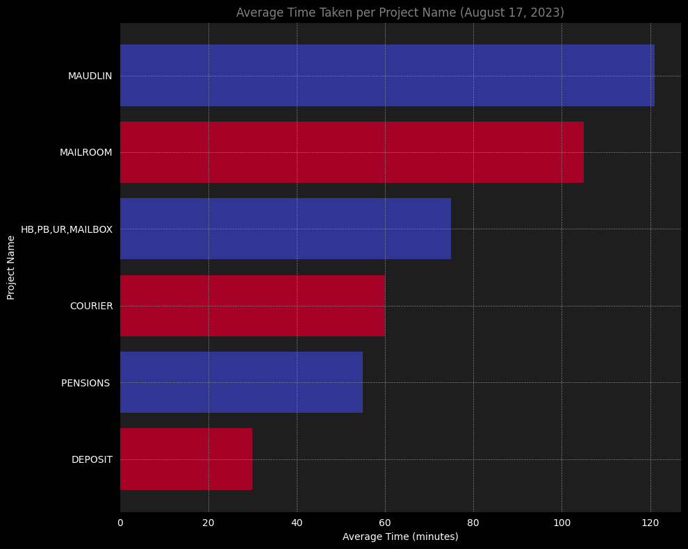

```python
# Converting the "Time (minutes)" column to a numerical data type
date_filtered_data['Time (minutes)'] = pd.to_numeric(date_filtered_data['Time (minutes)'], errors='coerce')

# Grouping by "Project " (with trailing space) and calculating the average time for the filtered data
project_time_avg = date_filtered_data.groupby('Project ')['Time (minutes)'].mean().sort_values(ascending=False).reset_index()

# Creating a color map to represent the time taken
colors = plt.cm.RdYlBu_r(np.linspace(0, 1, len(project_time_avg.columns)))

# Setting up the plot
plt.figure(figsize=(10, 8), facecolor='black')
plt.barh(project_time_avg['Project '], project_time_avg['Time (minutes)'], color=colors)
plt.gca().invert_yaxis()  # Inverting y-axis to have the shortest average time at the bottom
plt.title('Average Time Taken per Project Name (August 17, 2023)', color='grey')
plt.xlabel('Average Time (minutes)', color='white')
plt.ylabel('Project Name', color='white')
plt.xticks(color='white')
plt.yticks(color='white')
plt.gca().set_facecolor('#1e1e1e')
plt.grid(color='gray', linestyle='--', linewidth=0.5)
plt.tight_layout()
plt.show()
```

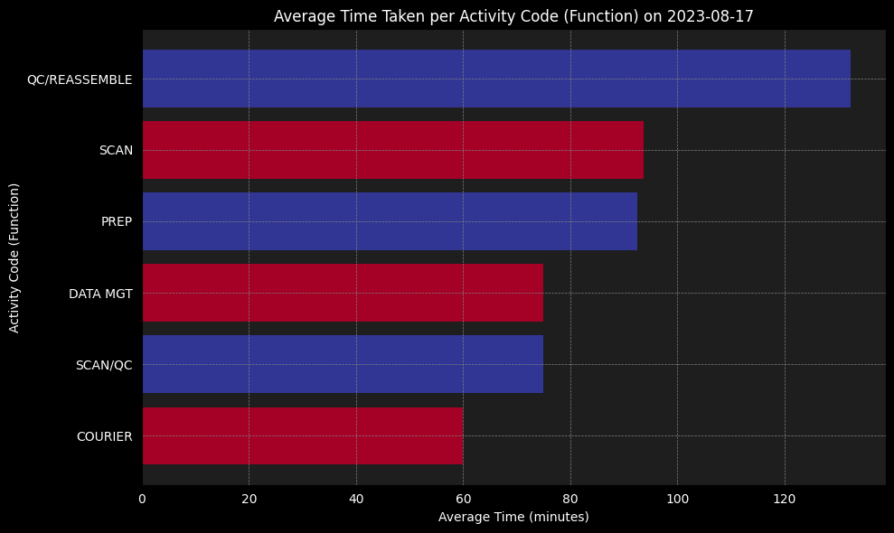

```python
# Grouping data by 'Function' (activity code) and calculating the average time taken
activity_code_avg_time = date_filtered_data.groupby('Function')['Time (minutes)'].mean().reset_index()
# Sorting the data by average time taken
activity_code_avg_time = activity_code_avg_time.sort_values(by='Time (minutes)', ascending=False)
# Creating a color map to represent the time taken
colors = plt.cm.RdYlBu_r(np.linspace(0, 1, len(activity_code_avg_time.columns)))


# Plotting the data
plt.figure(figsize=(10, 6), facecolor='black')
plt.barh(activity_code_avg_time['Function'], activity_code_avg_time['Time (minutes)'], color= colors)
plt.title('Average Time Taken per Activity Code (Function) on 2023-08-17', color='white')
plt.xlabel('Average Time (minutes)', color='white')
plt.ylabel('Activity Code (Function)', color='white')
plt.xticks(color='white')
plt.yticks(color='white')
plt.gca().invert_yaxis() # Inverting y-axis to have shortest average time at the bottom
plt.grid(color='gray', linestyle='--', linewidth=0.5)
plt.gca().set_facecolor('#1e1e1e')
plt.tight_layout()
plt.show()
```

Average Time Taken per Activity Code (Function):

Summary: This horizontal bar chart visualizes the average time taken for different activity codes (functions).

Insights: We can identify which functions take the longest and shortest time on average. This information can guide process optimization and task allocation.

QC/REASSEMBLE: take the most time on average, with about 130 minutes per task.

SCAN: Scanning tasks take around 90 minutes on average.

PREP: Prep tasks take around 90 minutes on average.

SCAN/QC: Scan and qc tasks take around 75 minutes on average.

DATA MGT: Data management tasks take around 75 minutes on average.

COURIER: Courier tasks take the least time, with around 60 minutes on average.

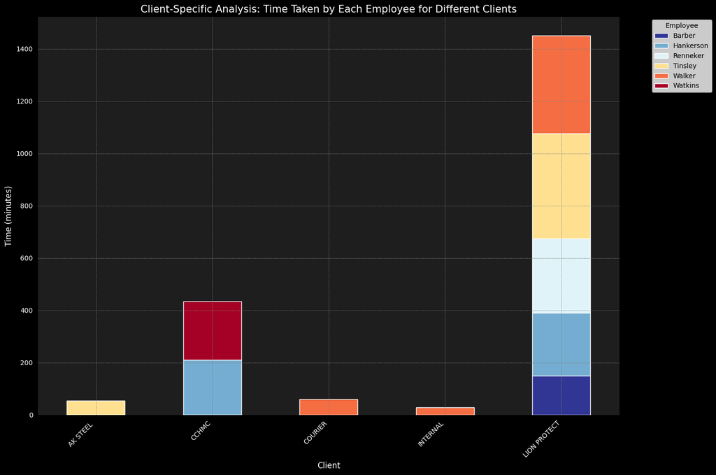

```python
# Client-Specific Analysis
plt.figure(figsize=(15, 10), facecolor='black')
client_employee_time = date_filtered_data.groupby(['Client', 'Staff'])['Time (minutes)'].sum().unstack().fillna(0)
# Creating a color map to represent the time taken
colors = plt.cm.RdYlBu_r(np.linspace(0, 1, len(client_employee_time.columns)))
# Plotting the stacked bar chart
client_employee_time.plot(kind='bar', stacked=True, color=colors, ax=plt.gca(), edgecolor='white')
# Adding labels, title, and legend
plt.title('Client-Specific Analysis: Time Taken by Each Employee for Different Clients', color='white', fontsize=15)
plt.xlabel('Client', color='white', fontsize=12)
plt.ylabel('Time (minutes)', color='white', fontsize=12)
plt.xticks(rotation=45, ha='right', color='white')
plt.yticks(color='white')
plt.legend(title='Employee', bbox_to_anchor=(1.05, 1), loc='upper left', fontsize=10)
plt.grid(color='gray', linestyle='--', linewidth=0.5)
# Customizing the plot appearance
plt.tight_layout()
plt.gca().set_facecolor('#1e1e1e')
# Show the plot
plt.show()
```

Client-Specific Analysis: Time Taken by Each Employee for Different Clients:

Summary: A stacked bar chart representing the time taken by each employee for different clients.

Insights: The distribution of time across different clients by each employee is clearly visible. This can help in understanding employee specialization or preferences in handling specific clients.

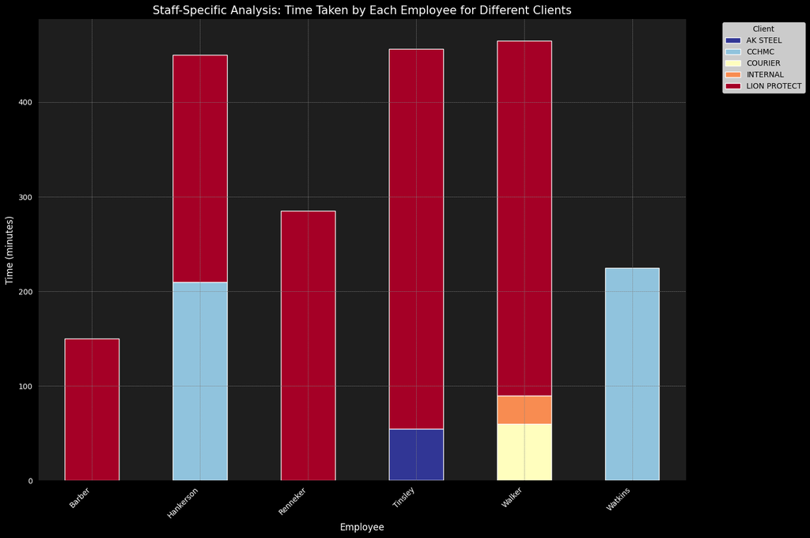

```python
# Staff-Specific Analysis
plt.figure(figsize=(15, 10), facecolor='black')

# Grouping data by Staff and Client, summing the Time (minutes)
staff_client_time = date_filtered_data.groupby(['Staff', 'Client'])['Time (minutes)'].sum().unstack().fillna(0)

# Creating a color map to represent the time taken
colors = plt.cm.RdYlBu_r(np.linspace(0, 1, len(staff_client_time.columns)))

# Plotting the stacked bar chart
staff_client_time.plot(kind='bar', stacked=True, color=colors, ax=plt.gca(), edgecolor='white')

# Adding labels, title, and legend
plt.title('Staff-Specific Analysis: Time Taken by Each Employee for Different Clients', color='white', fontsize=15)
plt.xlabel('Employee', color='white', fontsize=12)
plt.ylabel('Time (minutes)', color='white', fontsize=12)
plt.xticks(rotation=45, ha='right', color='white')
plt.yticks(color='white')
plt.legend(title='Client', bbox_to_anchor=(1.05, 1), loc='upper left', fontsize=10)
plt.grid(color='gray', linestyle='--', linewidth=0.5)

# Customizing the plot appearance
plt.tight_layout()
plt.gca().set_facecolor('#1e1e1e')

# Show the plot
plt.show()
```

Staff-Specific Analysis: Time Taken by Each Employee for Different Clients:

Summary: Similar to the previous chart but transposed, showing the time taken for different clients by each employee.

Insights: This chart provides an alternative perspective on how each staff member allocates their time among different clients, enabling targeted training or reassignment.

Summary of the Client-Specific Analysis and Staff-Specific Analysis Chart The stacked bar chart we generated illustrates the distribution of time taken by each staff member across different clients. Here's what we can infer from the chart:

Time Distribution: Some employees have a significant spread of time across different clients, indicating a diverse workload. Others focus more on specific clients, possibly reflecting specialization or project assignment.

High Time Consumption Clients: Certain clients may consistently take more time across various staff members. This pattern might imply that tasks related to these clients are more complex or that there are communication challenges that extend the time needed to complete tasks.

Staff Specialization: The chart might reveal that some staff members predominantly work with certain clients. This could be strategic, based on the employee's expertise, or it might highlight an uneven distribution of workload.

Potential Efficiency Insights: Comparing the time taken across employees for the same client might expose differences in efficiency or approach. These variations could be leveraged to optimize processes and workload distribution.

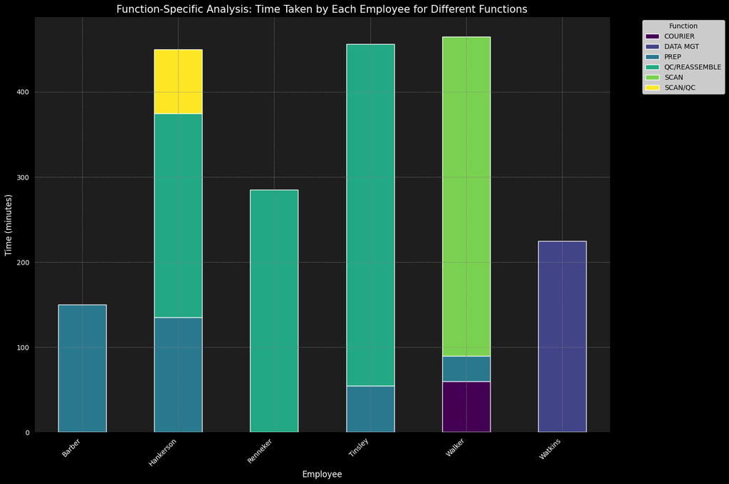

```python
# Function-Specific Analysis for Each Employee
# Grouping data by Staff and Function, summing the Time (minutes)
staff_function_time = date_filtered_data.groupby(['Staff', 'Function'])['Time (minutes)'].sum().unstack().fillna(0)

# Creating a color map to represent the time taken
colors = plt.cm.viridis(np.linspace(0, 1, len(staff_function_time.columns)))

# Plotting the stacked bar chart
plt.figure(figsize=(15, 10), facecolor='black')
staff_function_time.plot(kind='bar', stacked=True, color=colors, ax=plt.gca(), edgecolor='white')

# Adding labels, title, and legend
plt.title('Function-Specific Analysis: Time Taken by Each Employee for Different Functions', color='white', fontsize=15)
plt.xlabel('Employee', color='white', fontsize=12)
plt.ylabel('Time (minutes)', color='white', fontsize=12)
plt.xticks(rotation=45, ha='right', color='white')
plt.yticks(color='white')
plt.legend(title='Function', bbox_to_anchor=(1.05, 1), loc='upper left', fontsize=10)
plt.grid(color='gray', linestyle='--', linewidth=0.5)

# Customizing the plot appearance
plt.tight_layout()
plt.gca().set_facecolor('#1e1e1e')

# Show the plot
plt.show()
```

Summary:

Diverse Task Distribution: We can see that the employees have engaged in various functions, and the distribution varies from person to person.

Dominant Functions: Some functions appear more prominently across employees, possibly indicating common or critical tasks.

Employee Specialization: Certain employees might have spent more time on specific functions, possibly reflecting their area of expertise or assigned responsibilities.

Time Allocation Insights: This chart helps in understanding how the time is allocated across different functions for individual employees, enabling better task planning and resource allocation.

The chart provides a comprehensive view of how each employee's work time is distributed across different functions, which can be valuable for managers and team leads in assessing performance, aligning tasks with skills, and optimizing workflows.

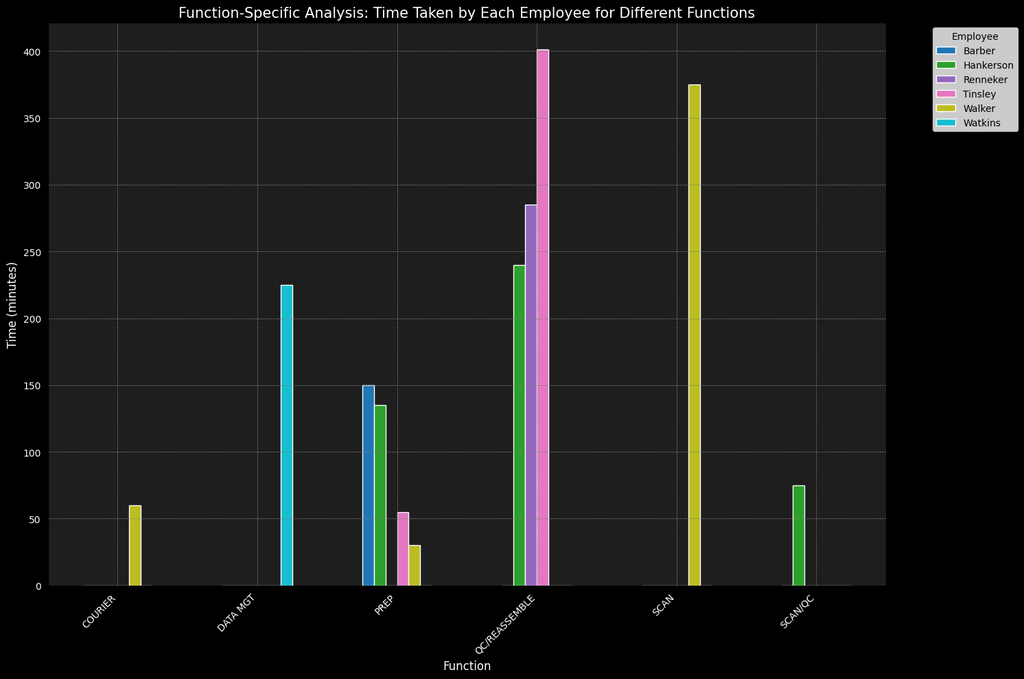

```python
# Importing required libraries
import matplotlib.pyplot as plt
import numpy as np

# Grouping data by Function and Employee, summing the Time (minutes)
function_employee_time = date_filtered_data.groupby(['Function', 'Staff'])['Time (minutes)'].sum().unstack().fillna(0)

# Creating a color map to represent different employees
colors = plt.cm.tab10(np.linspace(0, 1, len(function_employee_time.columns)))

plt.figure(figsize=(15, 10), facecolor='black')

# Plotting the grouped bar chart
ax = function_employee_time.plot(kind='bar', ax=plt.gca(), color=colors, edgecolor='white')

# Adding labels, title, and legend
plt.title('Function-Specific Analysis: Time Taken by Each Employee for Different Functions', color='white', fontsize=15)
plt.xlabel('Function', color='white', fontsize=12)
plt.ylabel('Time (minutes)', color='white', fontsize=12)
plt.xticks(rotation=45, ha='right', color='white')
plt.yticks(color='white')
plt.legend(title='Employee', bbox_to_anchor=(1.05, 1), loc='upper left', fontsize=10)
plt.grid(color='gray', linestyle='--', linewidth=0.5)

# Customizing the plot appearance
plt.tight_layout()
plt.gca().set_facecolor('#1e1e1e')

# Save the plot
#plot_path = "/mnt/data/function_specific_analysis.png"
#plt.savefig(plot_path)

# Show the plot
plt.show()
```

Here is the function-specific analysis plot that shows the distribution of tasks across different functions for every employee:

Function-Specific Analysis: This chart illustrates the time taken by each employee for different functions. The distribution of colors represents different employees, and the height of the bars indicates the total time spent on each function.

Implications: Understanding how tasks are distributed across functions and employees can guide resource allocation, task assignment, and employee training. It can also help in identifying areas where additional support or efficiency improvements are needed.

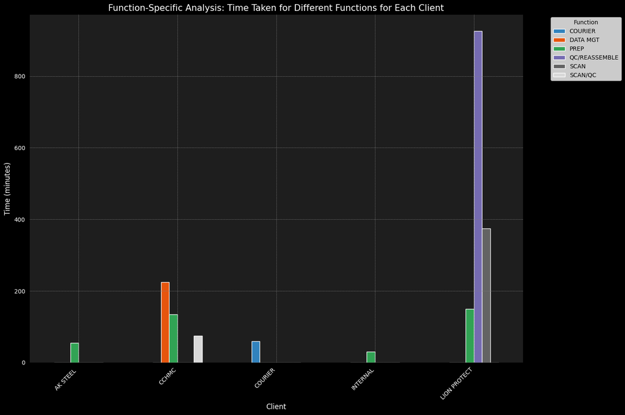

```python
# Converting the "Time (minutes)" column to a numerical type
date_filtered_data['Time (minutes)'] = pd.to_numeric(date_filtered_data['Time (minutes)'], errors='coerce')

# Grouping data by Client, Function, and Employee, summing the Time (minutes)
client_function_time = date_filtered_data.groupby(['Client', 'Function'])['Time (minutes)'].sum().unstack().fillna(0)

# Creating a color map to represent different functions
colors = plt.cm.tab20c(np.linspace(0, 1, len(client_function_time.columns)))

# Plotting the grouped bar chart
plt.figure(figsize=(15, 10), facecolor='black')
client_function_time.plot(kind='bar', ax=plt.gca(), color=colors, edgecolor='white')

# Adding labels, title, and legend
plt.title('Function-Specific Analysis: Time Taken for Different Functions for Each Client', color='white', fontsize=15)
plt.xlabel('Client', color='white', fontsize=12)
plt.ylabel('Time (minutes)', color='white', fontsize=12)
plt.xticks(rotation=45, ha='right', color='white')
plt.yticks(color='white')
plt.legend(title='Function', bbox_to_anchor=(1.05, 1), loc='upper left', fontsize=10)
plt.grid(color='gray', linestyle='--', linewidth=0.5)

# Customizing the plot appearance
plt.tight_layout()
plt.gca().set_facecolor('#1e1e1e')

# Show the plot
plt.show()
```

The function-specific analysis for each client has been visualized in the bar plots above. Below are the summaries and insights we can draw from these plots:

Interpretation:

Variation in Functions: The chart illustrates how different functions are distributed across various clients. Some clients have more time allocated to specific functions, while others have a more balanced distribution.

Client Needs: By analyzing the heights of the bars, we can discern the functions that are most time-consuming for individual clients. This information can be valuable for future planning and resource allocation.

Comparison Across Clients: The chart enables a direct comparison of how different clients utilize various functions. This might reveal trends or preferences that could be explored further.

Insights:

Identify Key Functions: Understanding the key functions for each client can lead to more targeted strategies and better client relationships.

Optimize Resource Allocation: By knowing the time required for different functions, resources can be allocated more efficiently.

Enhance Collaboration: Sharing this information with team members can foster collaboration and ensure that everyone is aligned with client needs and expectations.

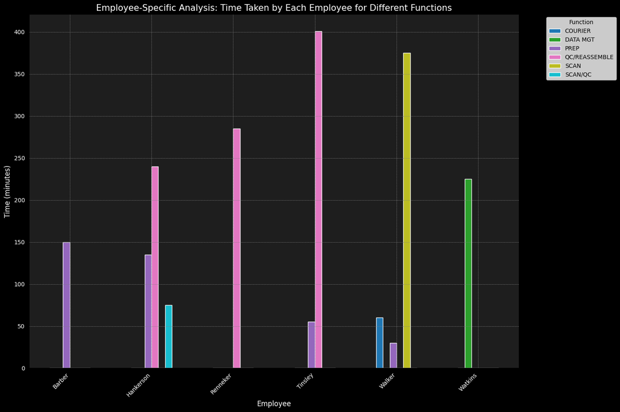

```python
# Transposing the data to have Employee as the index and Function as columns
employee_function_time = function_employee_time.transpose()

# Creating a color map to represent different functions
colors = plt.cm.tab10(np.linspace(0, 1, len(employee_function_time.columns)))

plt.figure(figsize=(15, 10), facecolor='black')

# Plotting the grouped bar chart
ax = employee_function_time.plot(kind='bar', ax=plt.gca(), color=colors, edgecolor='white')

# Adding labels, title, and legend
plt.title('Employee-Specific Analysis: Time Taken by Each Employee for Different Functions', color='white', fontsize=15)
plt.xlabel('Employee', color='white', fontsize=12)
plt.ylabel('Time (minutes)', color='white', fontsize=12)
plt.xticks(rotation=45, ha='right', color='white')
plt.yticks(color='white')
plt.legend(title='Function', bbox_to_anchor=(1.05, 1), loc='upper left', fontsize=10)
plt.grid(color='gray', linestyle='--', linewidth=0.5)

# Customizing the plot appearance
plt.tight_layout()
plt.gca().set_facecolor('#1e1e1e')

# Save the plot
#plot_path = "/mnt/data/employee_function_analysis.png"
#plt.savefig(plot_path)

# Show the plot
plt.show()
```

Employee-Specific Analysis: Time Taken by Each Employee for Different Functions:

Summary: A grouped bar chart that represents the time taken by each employee for different functions.

Insights: This provides an employee-centric view of task distribution, revealing possible areas for cross-training or specialization.

Insights:

Employee Specialization: The chart allows us to see if certain employees are specialized in particular functions. This can be useful for task assignment and team composition.

Balanced Distribution: We can evaluate whether there is a balanced distribution of functions across employees, which might reflect an equitable workload.

Identify Bottlenecks: If an employee is spending a disproportionate amount of time on a specific function, it might indicate a bottleneck or a need for additional training.

Optimize Resource Allocation: Understanding how time is spent across functions for each employee can lead to more effective resource allocation and productivity enhancement.

Enhance Collaboration: The visualization fosters a clear understanding of roles and responsibilities, enabling better collaboration and alignment within the team.

The plot provides a comprehensive view of how different functions are distributed across employees, paving the way for strategic decisions and continuous improvement.